# Student Sit In

Nicolas Rizo

10/28/2019

# ONE SHOT assignment!

this is an extra credit assignment, must be completed Monday Oct 28, turn-in closes at midnight!

## Problem statement:

Students at UCD- is there a relation between where one sits and one’s major?

## Introduction

$H_0$: there is no relationship between one’s major and where one sits in a class  
$H_A$: where one sits in class and one’s major are related

names of the data in the data frame

```
##  [1] "seat"           "major"          "data.Sex"       "data.TV"
##  [5] "data.computer"  "data.Sleep"     "data.Seat"      "data.alcohol"
##  [9] "data.Height"    "data.momheight" "data.dadheight" "data.exercise"
## [13] "data.GPA"       "data.class"
```

## Methods

Both variables in this are categorical. We will use a bar chart to show th graphical data, a cross table to show the numerical summary, and a Chi-Squared test to show the inferential results.

## Data summary

**Graphical summary**

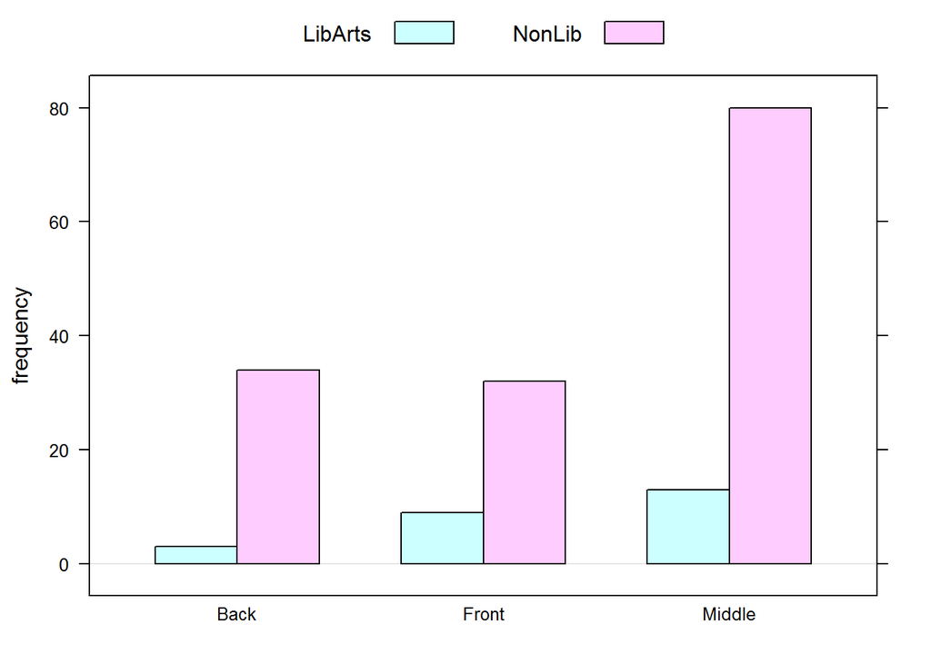

```r
barchartGC(~"seat"+"major",data=UCDdataframe)
```

The graph is showing thata a mojority of the Non-Liberal Arts students prefer to be seated in the middle. More of the Liberal Arts students prefer to be seated in the middle than in the back or towards the front.

```r
tab=xtabs(~seat+major,data =UCDdataframe)
print(tab)
```

```
##         major
## seat     LibArts NonLib
##   Back         3     34
##   Front        9     32
##   Middle      13     80
```

The numerical table suggests that Liberal Arts students prefer to sit in the muiddle and Non-Liberal Arts students prefer to sit in the middle.

## Inferential Results

```r
chisqtestGC(tab)
```

```
## Pearson's Chi-squared test
##
## Observed Counts:
##         major
## seat     LibArts NonLib
##   Back         3     34
##   Front        9     32
##   Middle      13     80
##
## Counts Expected by Null:
##         major
## seat     LibArts NonLib
##   Back      5.41  31.59
##   Front     5.99  35.01
##   Middle   13.60  79.40
##
## Contributions to the chi-square statistic:
##         major
## seat     LibArts NonLib
##   Back      1.07   0.18
##   Front     1.51   0.26
##   Middle    0.03   0.00
##
##
## Chi-Square Statistic = 3.053
## Degrees of Freedom of the table = 2
## P-Value = 0.2173
```

The P-Value is 0.2173